# Praca domowa 2

Sebastian Botero Leonik

## Dane

Dane wykorzystane w Pracy domowej 2 opisują wycenę nieruchmości. Każda obserwacja jest pewną nieruchmością, która posiada informacje takie jak powierzchnia, liczba pokoi, liczba łazienek i wiele więcj. Opis wszystkich kolumn w pliku `README.md`.

## Zadanie 1

Jak wygląda rozkład ceny nieruchomości w poszczególnych kodach pocztowych na przestrzeni lat? Rozważamy kody pocztowe, które mają więcej niż 280 posiadłości.

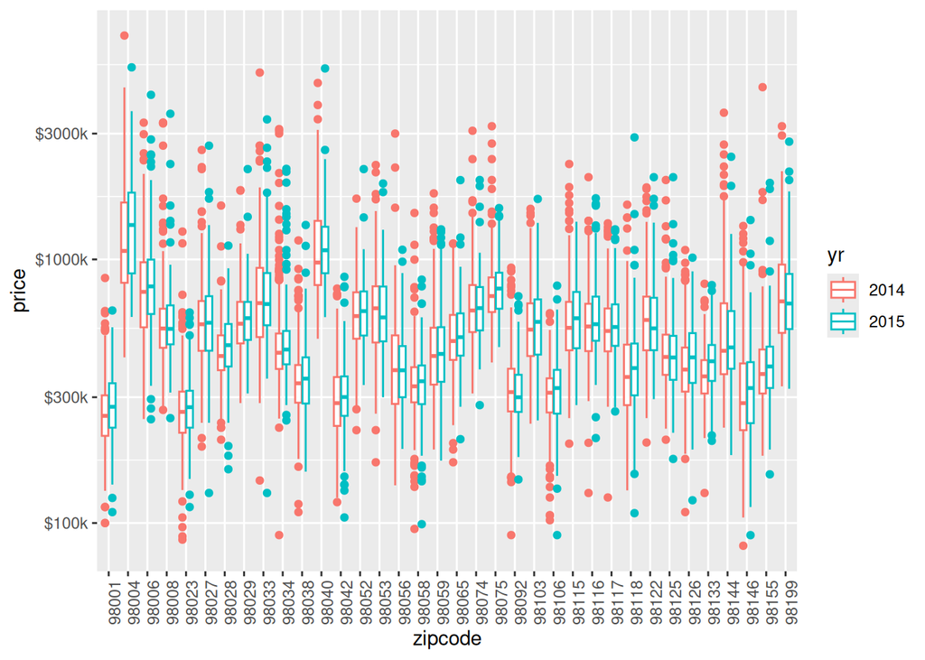

```r
# Tu umieść kod do wygenerowania odpowiedzi do zadania.
target_zipcodes <- df |>
  group_by(zipcode) |>
  summarise(n = n()) |>
  filter(n > 280) |>
  select(zipcode)

df |>
  right_join(target_zipcodes) |>
  mutate(zipcode = factor(zipcode), yr = substr(date, 1, 4)) |>
  ggplot(aes(y = price, x = zipcode, colour = yr)) +
  scale_y_log10(labels = (\(x) paste("$", x/1000, "k", sep = ""))) +
  geom_boxplot(
    # colour = "#3e8146"
    ) +
  theme(axis.text.x = element_text(angle = 90))
```

```r
  # facet_wrap(facets = vars(yr))
```

**Komentarz:**

## Zadanie 2

Czy jest różnica w rozkładzie ceny nierchomości od powierzchni mieszkalnej uwzględniając podział na nieruchomości z piwnicą i bez?

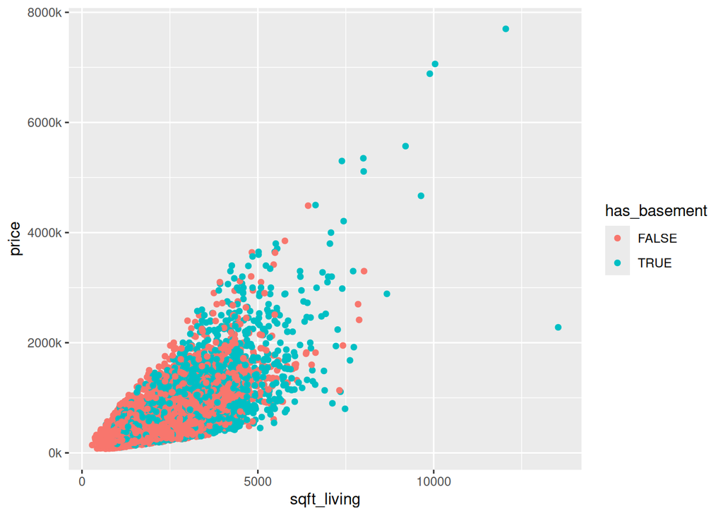

```r
options(scipen = 12)

# Tu umieść kod do wygenerowania odpowiedzi do zadania.
df |>
  mutate(has_basement = sqft_basement > 0)|>
  ggplot(aes(x = sqft_living, y = price, colour = has_basement)) +
  scale_y_continuous(labels = (\(x) paste(x/1000, "k", sep = ""))) +
  geom_point()
```

**Komentarz:**

Ogólny rozkład jest bardzo podobny i można go ograniczyć tymi samymi półprostymi w układzie współrzędnych, ale najdroższe i największe nieruchomości mają piwnicę, zaś większość tanich i małych mieszkań nie ma piwnicy

## Zadanie 3

Jaka jest zależność pomiędzy jakością wykończenia nieruchomości a liczbą pięter?

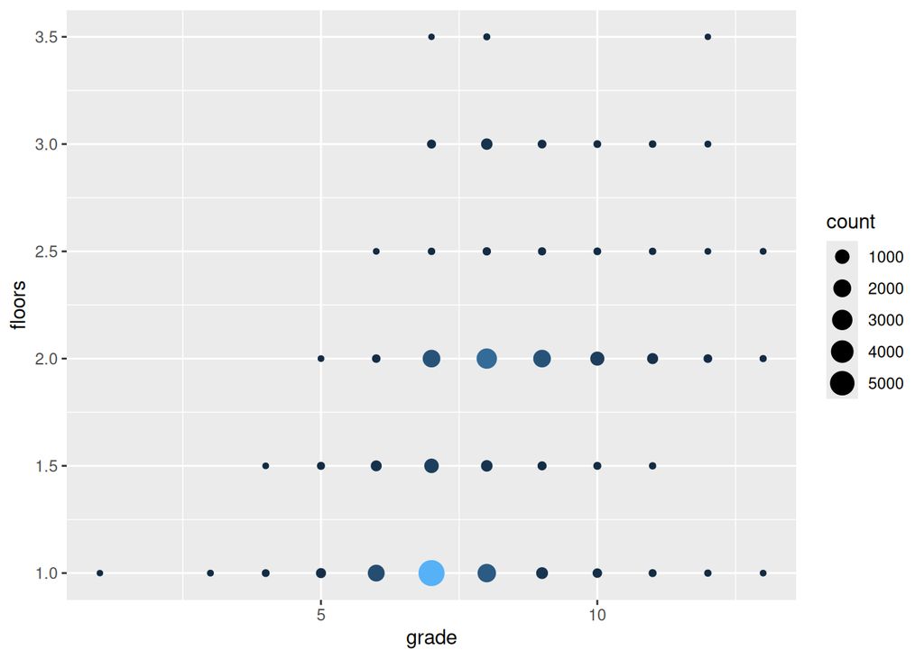

```r
# Tu umieść kod do wygenerowania odpowiedzi do zadania.

df |>
  group_by(grade, floors) |>
  summarise(count = n()) |>
  ggplot(aes(x = grade, y = floors, size = count, colour = count)) +
  geom_point() +
  guides(colour = FALSE)
```

**Komentarz:**

Posiadłości mające dużo pięter rzadko są słabo wykonane, choć wysoka jakość wykonania nie wymaga wielu pięter. Najwięcej jest niskich budynków o nienajlepszej i nieajgorszej jakości wykonania

## Zadanie 4

Jaka jest zależność między powierzchnią mieszkalną nieruchomości a powierzchnią gruntu w podziale na liczbę sypialni?

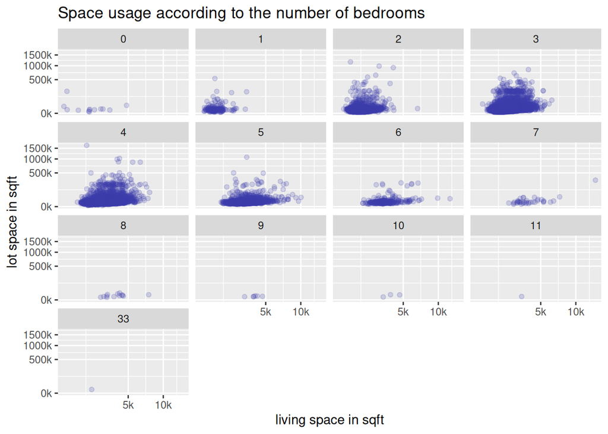

```r
# Tu umieść kod do wygenerowania odpowiedzi do zadania.

df |>
  ggplot(aes(x = sqft_living, y = sqft_lot)) +
  geom_point(colour = "#3e3fab30") +
  facet_wrap(facets = vars(bedrooms)) +
  scale_y_sqrt(labels = (\(x) paste(x/1000, "k", sep = ""))) +
  scale_x_sqrt(labels = (\(x) paste(x/1000, "k", sep = ""))) +
  labs(title = "Space usage according to the number of bedrooms",x = "living space in sqft", y = "lot space in sqft")
```

**Komentarz:**

Na wykresach widać, że posiadłości o dużej powierzchni całego terenu z reguły nie mają budynków z wieloma sypialniami. Z reguły te wielkie działki mają 2-5 sypialni. W zestawie danych jest bardzo niewiele budynków bez sypialni jak i mających więcej niż 7 sypialni

## Zadanie 5

Rozważmy tylko nieruchomości, które miały remont. W której dekadzie było najwięcej przeprowadzonych remontów? Czy w poszczególnych dekadach jest porównywalny procent nieruchmości dla każdej wartości miary jakości i wykończenia nieruchomości?

[figure not shown]

```r
# Tu umieść kod do wygenerowania odpowiedzi do zadania.
df_decades <- df |>
  filter(yr_renovated != 0) |>
  mutate(decade = 10*(yr_renovated %/% 10)) |>
  select(decade, grade)


df_decades |>
  group_by(decade, grade) |>
  summarise(count = n()) |>
  left_join(
    df_decades |>
      group_by(decade) |>
      summarise(total_count = n())
  ) |>
  group_by(decade, grade, count, total_count) |>
  summarise() |>
  mutate(decade_lab = paste("Decade: ", decade, "s", sep = ""), total_count_lab = paste("Amount of houses built:", total_count),
         percentage = 100 * count/total_count) |>
  ggplot(aes(x = grade, y = percentage)) +
  geom_bar(stat = "identity") +
  facet_wrap(vars(decade_lab, total_count_lab))
```

**Komentarz:**

## Zadanie 6

Jak prezentuje się wartość minimalna, średnia i maksymalna ceny nieruchmości w podziele na rok budowy nieruchomości.

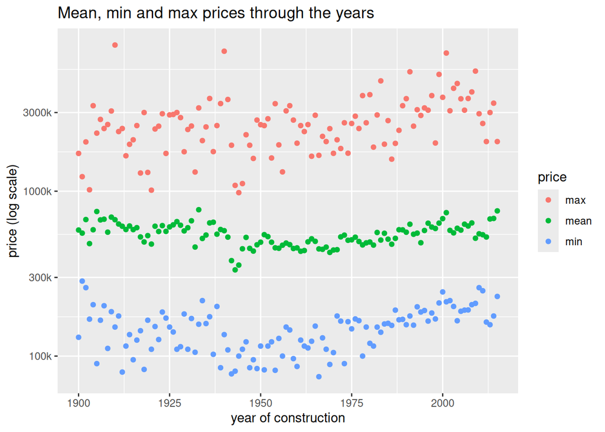

```r
# Tu umieść kod do wygenerowania odpowiedzi do zadania.

df |>
  group_by(yr_built) |>
  summarise(min = min(price), max = max(price), mean = mean(price)) |>
  tidyr::pivot_longer(!yr_built, names_to = "price", values_to = "value") |>
  ggplot(aes(x = yr_built, colour = price, y = value)) +
  # geom_line() +
  geom_point() +
  scale_y_log10(labels = (\(x) paste(x/1000, "k", sep = ""))) +
  labs(title = "Mean, min and max prices through the years",
       y = "price (log scale)",
       x = "year of construction")
```

```r
  # geom_point(aes(y = min)) +
  # geom_point(aes(y = max)) +
  # geom_point(aes(y = mean))
```

**Komentarz:**

Wykresy tych wielkości na skali logarytmicznej są w podobnych odstępach, co oznacza, że wartość minimalna jest ±tyle samo razy mniejsza od średniej, co średnia od maksymalnej. Zarówno wartości minimalne jak i maksymalne mają dość znaczące zmiany względne patrząc pomiędzy kolejnymi latami budowy. Średnia jest dużo bardziej stabilna, mając z reguły dużo mniejsze różnice pomiędzy kolejnymi rocznikami budynków